# Project 2D Michael Li

# Introduction and Background

Scientific Question: What differences in the sequences of each segment of the segmented genome and expression of infected cells exist between the H1N1 from the 2009 Swine flu pandemic and non-pandemic H1N1 (specifically the strain A/Puerto Rico/8/1934) that may contribute to differences in severity?

Hypothesis: If there is a difference in gene sequences, then severity related differences will be seen in the NS1 and NS2 sequences with pandemic strains having more closely correlated scores and seasonal strains having closely correlated scores, and if there is a difference in transcription of infected cells, then we should see different levels of expression for immune system related genes with pandemic strains inducing higher levels of expression of those genes.

This project will be looking at the differences between the genes in pandemic strains of H1N1 and H3N2 (pH1N1 and pH3N2) and seasonal strains of H1N1 and H3N2 (sH1N1 and sH3N2). For pH1N1, we will be using sequences from A/California/04/2009 (CA04) and A/USSR/90/1977 (USSR90). For sH1N1, we will be using sequences from A/Alabama/01/2020 (AL90) and A/PR/8/1934 (PR8). For pH3N2, we will be using sequences from A/HK/1-1-MA-12/1968. For sH3N2, we will be using sequences from A/Delaware/05/2020 (DE05).

In addition to looking at the different sequences of segments, this project will also be looking at the differences in host cell responses by looking at RNAseq data of infected cells’ transcriptome (comparing between PR8 infected cells and CA01 infected cells; CA01 is also from the 2009 H1N1 pandemic). The cells used in this experiment are A549 immortalized lung epithelial cells.

## Previous Literature

I hypothesize that we will see different levels of expression for immune system related genes because in previous literature about transcriptoem analysis of PR8 infected A549 cells found that infection leads to enriched immune signaling and cytokine production, especially IL-17A and other related molecules. It was also found that IL-17A facilitated viral infection and that IL-17A knockout mice exhibited less weight loss and lung immunopathology compared to wild type mice (Li 2019).

In a previous study comparing pH1N1 to sH1N1 and sH3N2, it was found that there were variations in the NS1 protein of pH1N1 that allowed it to inhibit host gene expression (Clark 2017). Hence, the hypothesis that bot hpandemic strains of H1N1 and H3N2 will have similar NS1 sequences separate from the seasonal strains.

Although my scientific question and hypothesis does not cover the structural protein (nucleoprotein), previous literature has established that pH1N1 has a different nucleoprotein that allows it to resist some interferon (IFN) induced degradation (Pagani 2018). This shows that for a strain to become a pandemic, it needs to undergo changes in various segments and parts of the viral life cycle. The data I am considering is only a small part of a multifaceted field.

# Data

Data for segment sequences was taken from NCBI found via fludb.org. The data for the transcription was from https://www.frontiersin.org/articles/10.3389/fmicb.2019.02344/full. Sequence data is analyzed through pairwise sequence alignment for each segment between various pandemic and seasonal strains. The scores are stored in a matrix and portrayed as a heatmap. Transcription data is in the form of the results of differential expression analysis of RPKM data. The data is analyzed through a volcano plot and pathway analysis (two analysis to make up for the lack of RNAseq due to dataset issues; as allowed by Dr. Schiffer).

```r
# Importing all necessary libraries

# The seqinr library is used to read in and perform data analysis on sequence data.Un-comment the line below to install package
# install.packages("seqinr")
library(seqinr)

# The Biostrings library is used as efficient string containers, string matching algorithm (sequence alignments), and others. Un-comment the 3 lines below to install.
# if (!require("BiocManager", quietly = TRUE))
#    install.packages("BiocManager")
# BiocManager::install("Biostrings")
library(BiocManager)
library(Biostrings)

# ggplot2 is included in R so it just needs to be loaded in. It is a library for creating plots. Here I use it to create the volcano plot.
library(ggplot2)

# The pheatmap library contains the function pheatmap() and is used to create heatmaps. Un-comment the next line to install the package.
# install.packages("pheatmap")
library(pheatmap)

# The dplyr library adds in various functions that help you manipulate data. Notably, I use the select() function for my code. Un-comment the line below to install the pacakge.
# install.packages("dplyr")
library(dplyr)

# The readxl library contains the read_excel() function I use to read in the RNAseq data. Un-comment the line below to isntall the package.
# install.packages("readxl")
library(readxl)

# The gageData library contains the data set for human biological pathways that we will be comparing our data set to. The gage library contains the gage() function that we will be using to perform the pathway analysis. The pathview library is used to generate the image of the given pathway with the relevant up and downregulated genes. Un-comment the line below to install the 3 packages.
# BiocManager::install( c("pathview", "gage", "gageData") )
library(gageData)
library(gage)
library(pathview)

# The png library will be used to read in the png files generated by pathview() as a bitmap. Un-comment the line below to install the package.
# install.packages("png")
library(png)

# The rasterImage library allows us to convert the bitmap read in by readPNG() into an image we can add to a plot. Un-comment the line below to install the package.
# install.packages("rasterImage")
library(rasterImage)
```

## Sequence alignment of various pandemic and seasonal strains of H1N1 and H3N2

```r
# loading in sequence files.Each contains 10 sequences. There are 8 segments with two segments coding for 2 proteins iether through alternative start codons or alternative splicing (m1 and m2; ns1 and ns2).

# H1N1 pandemic strain
h1n1_ca2009 <- read.fasta("A_California_04_2009.fasta")

# H1N1 pandemic strain
h1n1_ussr1977 <-read.fasta("A_USSR_90_1977.fasta")

# H1N1 seasonal strain
h1n1_al2020 <- read.fasta("A_Alabama_01_2020.fasta")

# H1N1 seasonal strain
h1n1_pr1934 <- read.fasta("A_PR_8_1934.fasta")

# H3N2 pandemic strain
h3n2_hk1968 <- read.fasta("A_HK_1-1-MA-12_1968.fasta")

# H3N2 seasonal strain
h3n2_de2020 <- read.fasta("A_Delaware_05_2020.fasta")

# Fit all the sequence
all_strains <- list(h1n1_ca2009, h1n1_ussr1977, h1n1_al2020, h1n1_pr1934, h3n2_hk1968, h3n2_de2020)

# Create a new empty list to store the sequences by segment instead of strain. The two numeric variables define the number of samples and number of proteins.
all_segs<-list()
num_samples<-6
num_prot <- 10

# Populating the list with all the segments.
for(i in 1:num_samples){
  all_segs$pb2[i] <- all_strains[[i]][1]
  all_segs$pb1[i] <- all_strains[[i]][2]
  all_segs$pa[i] <- all_strains[[i]][3]
  all_segs$ha[i] <- all_strains[[i]][4]
  all_segs$np[i] <- all_strains[[i]][5]
  all_segs$na[i] <- all_strains[[i]][6]
  all_segs$m1[i] <- all_strains[[i]][7]
  all_segs$m2[i] <- all_strains[[i]][8]
  all_segs$ns1[i] <- all_strains[[i]][9]
  all_segs$ns2[i] <- all_strains[[i]][10]
}

# Generate two vectors, one for all the protein names, and one for all the sample names for the heatmap.
protein_names <- c("PB2", "PB1", "PA", "HA", "NP", "NA", "M1", "M2", "NS1", "NS2")
labels <- c("h1n1_P_ca2009", "h1n1_P_ussr1977", "h1n1_S_al2020", "h1n1_S_pr1934", "h3n2_P_hk1968", "h3n2_S_de2020")

# Naming all the samples
for(i in 1:num_prot){
  names(all_segs[[i]]) <- labels
}
```

## Function for generating a heatmap based on sequence scores by taking in sequence data (as SeqFastadna data type) and the name of the protein being observed.

```r
heatmapMatrix <- function(sequences, protein_name) {
  scores <- matrix(nrow = length(sequences), ncol = length(sequences))

  # Here is a loop that populates each matrix with the appropriate score comparisons.The pairwiseAlignment function takes in two sequences in the form of a string/character vector of equal length and the score function extracts the scores. As there can be variations between the lengths of the sequences, I made all of them into a single string.
  for (i in 1:num_samples){

    prot1 <- paste(as.character(sequences[[i]]),collapse='')

    for (j in 1:num_samples){
      prot2 <- paste(as.character(sequences[[j]]),collapse='')
      scores[i,j] <- score(pairwiseAlignment(prot1, prot2))
    }
  }
  heatmap(scores, main = protein_name, labRow = labels, labCol = labels, scale = "row", cexRow = 0.65, cexCol = 0.65)
}
```

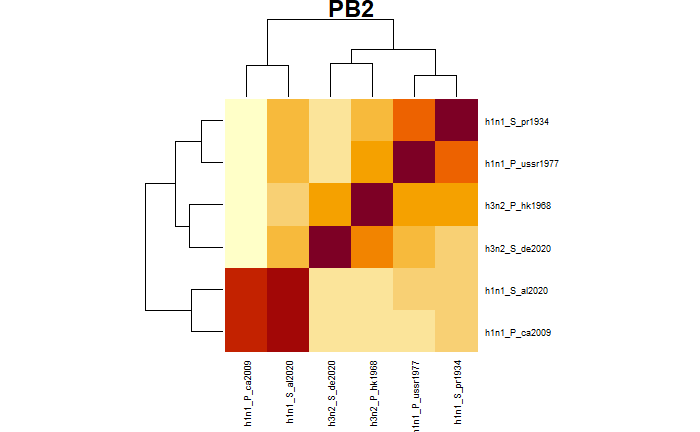

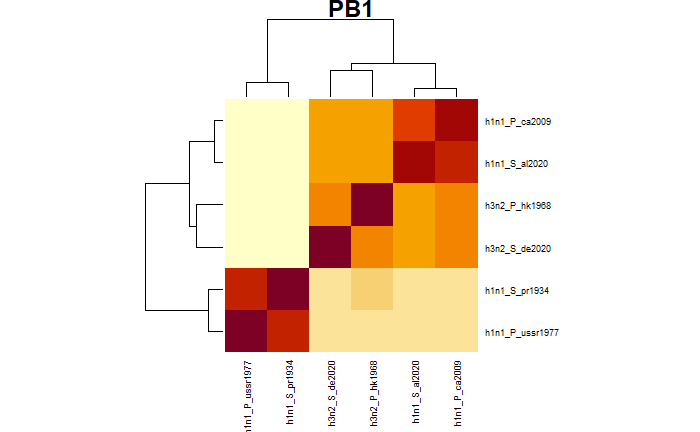

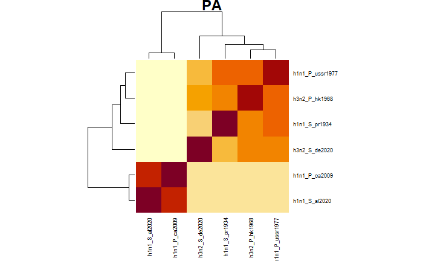

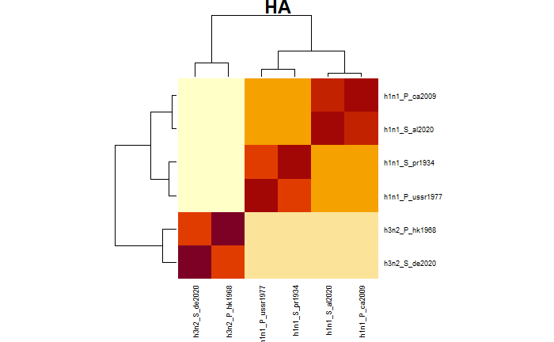

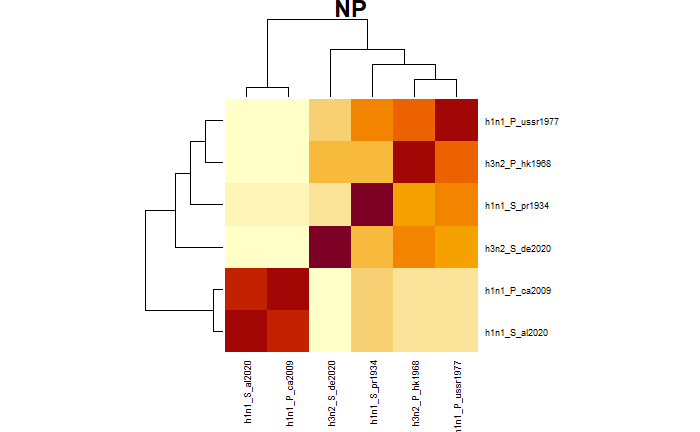

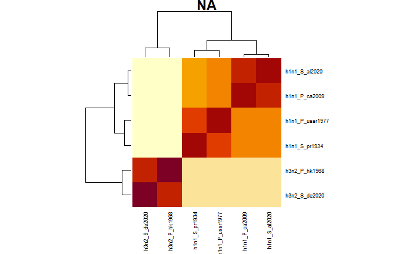

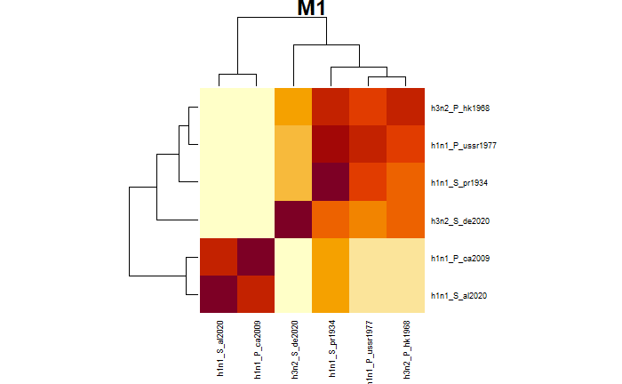

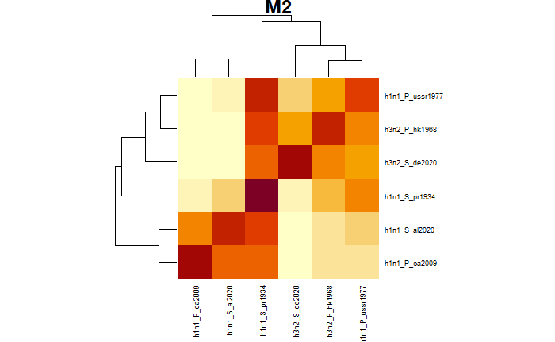

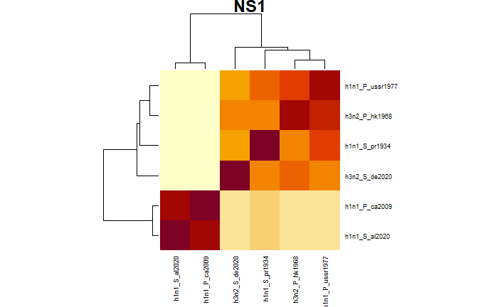

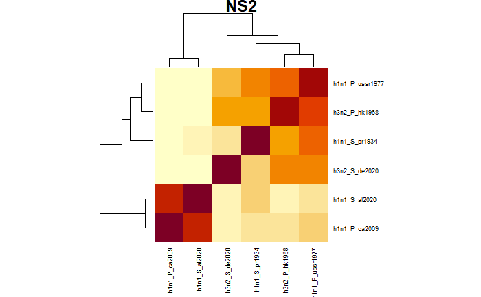

```r
# Here I call the function for all of the proteins that can be made by the 8 segments of influenza A.
for (i in 1:num_prot){
  heatmapMatrix(all_segs[[i]], protein_names[i])
}
```

## Analysis of sequence alignment results

Overall, the H1N1 seasonal strain from Alabama and pandemic strain from California correlate with each other most likely due to geography. Darker red indicates higher degree of similarity with the corresponding strains. The dendrograms are there as a quick way to see how each strain relates to one another in the context of the specified protein sequence.As expected, the H1N1 and H3N2 strains correlate heavily within their own groups for the HA and NA proteins as by definition the H and N refers to those two segments/proteins.Data here is more useful in tracing where segments were conserved and where they were taken from another strain within the same HxNy group. For example, both ca2009 and al2020 shares some correlation with the pr1934 seasonal strain. Interestingly enough, the pandemic strain of H1N1 in the USSR in 1977 shares a strong correlation with the pandemic strain of H3N2 in Hong Kong in 1968 for the NS1/NS2 segment/proteins. However, it is not correlated with the pandemic strain in California in 2009. Co-infection of a host by a descendant of the 1968 strain and a predecessor of the 1977 strain could have allowed exchange of the segment. It could also be a case of convergent evolution towards a more similar NS1/NS2. As the non-structural proteins are known to be used to aid in repressing host interferon pathway and pro-inflammatory responses (Clark 2017). It would further benefit to see the sequential and structural differences and similarities of various strains’ NS1 and NS2 genes and proteins, respectively.

# RNAseq analysis of RPKM

In this section I will be reading in finished RNAseq data (post-DEseq) and be analyzing the data using heatmap, volacano plot, and pathway analysis. Each analysis method will have its own superficial description/analysis at the end of their section, and there will be an overall analysis discussing the significance of the findings and the functions of previously mentioned genes and pathways.

## Read in data and transform data to fit further analysis

```r
# Here I read in the data from the provided files that include the log2ratio of infected/control expressions.
res_ca01 <- as.data.frame(read_excel("A549_CA01.xlsx", col_names = TRUE))
res_pr8 <- as.data.frame(read_excel("A549_PR8.xlsx", col_names = TRUE))

# After reading in the table, I do some transformations so I end up with only the log2ratios and pvalues.
rownames(res_ca01) <- res_ca01[,11]
ca01_geneid <- res_ca01[,1]
res_ca01 <- res_ca01[,-8]
res_ca01 <- res_ca01[,7:8]
res_ca01$geneID <- ca01_geneid
res_ca01 <- res_ca01[order(res_ca01$pvalue),]
rownames(res_pr8) <- res_pr8[,11]
pr8_geneid <- res_pr8[,1]
res_pr8 <- res_pr8[,-8]
res_pr8 <- res_pr8[,7:8]
res_pr8$geneID <- pr8_geneid
res_pr8 <- res_pr8[order(res_pr8$pvalue),]

# I subset it to only include the statistically significant. Although it may be more beneficial to look at all the genes in the seasonal strain. It can also be interesting to look to see if upregulated genes in ca01 infected cells are downregulated in PR8 infected cells.
res_ca01_sig <- subset(res_ca01, res_ca01$pvalue < 0.05)
res_pr8_sig <- subset(res_pr8, res_ca01$pvalue < 0.05)
```

```r
# To make analysis simpler, I subseted both to only include genes that overlap between the two.
sub_res_pr8 <- subset(res_pr8_sig, rownames(res_pr8_sig) %in% rownames(res_ca01_sig))
sub_res_ca01 <- subset(res_ca01_sig, rownames(res_ca01_sig) %in% rownames(sub_res_pr8))

# I combine the two data frames to draw the heatmap and volcano plot for later.
combined_res <- data.frame(sub_res_ca01$`log2_Ratio(A549_CA01/A549_Control)`, sub_res_pr8$`log2_Ratio(A549_PR8/A549_Control)`, sub_res_ca01$pvalue, sub_res_pr8$pvalue)
rownames(combined_res)<-rownames(sub_res_pr8)
colnames(combined_res) <- c("CA01_infected", "PR8_infected", "CA01_pvalue", "PR8_pvalue")
```

## Generating heatmap

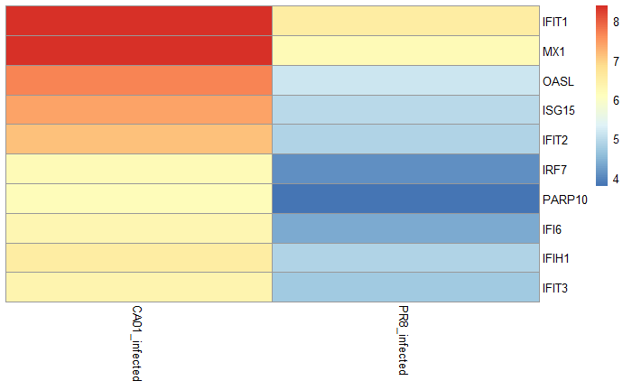

```r
# I generate a heatmap for the top 10 DEGs.
sub_combined <- head(as.matrix(combined_res), n =10)
pheatmap(sub_combined[,1:2],
         cluster_rows = T,
         show_rownames = T, row.names = rownames(sub_combined[,1:2]), treeheight_row = 0, treeheight_col = 0)
```

```r
# In this chunk, I am interested in seeing if there are up regulated genes in the CA01 group that are down regulated in the PR8 group and vice versa.
res_ca01_up <- subset(res_ca01_sig, res_ca01_sig$`log2_Ratio(A549_CA01/A549_Control)` > 0)
res_ca01_down <- subset(res_ca01_sig, res_ca01_sig$`log2_Ratio(A549_CA01/A549_Control)` < 0)
res_pr8_up <- subset(res_pr8_sig, res_pr8_sig$`log2_Ratio(A549_PR8/A549_Control)` > 0)
res_pr8_down <- subset(res_pr8_sig, res_pr8_sig$`log2_Ratio(A549_PR8/A549_Control)` < 0)

ca01_up_pr8_down <- subset(res_ca01_up, rownames(res_pr8_down) %in% rownames(res_ca01_up))
ca01_down_pr8_up <- subset(res_ca01_down, rownames(res_pr8_up) %in% rownames(res_ca01_down))

# Prints out genes that are upregulated in CA01 infected A549 cells and are downregulated in PR8 infected A549 cells.
rownames(ca01_up_pr8_down)
```

```
[1] "NPHS1"
```

```r
# Prints out genes that are downregulated in CA01 infected A549 cells and are upregulated in PR8 infected A549 cells.
rownames(ca01_down_pr8_up)
```

```
character(0)
```

## Generating volcano plot

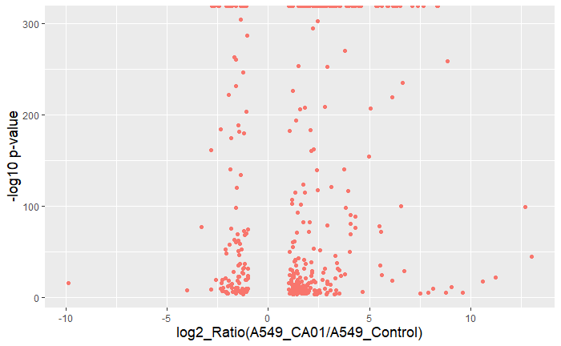

```r
# Here I generated the volcano plot.
combined_res$CA01_threshold <- combined_res$CA01_pvalue < 0.05
combined_res$PR8_threshold <- combined_res$PR8_pvalue < 0.05
ggplot(combined_res) +
        geom_point(aes(x = CA01_infected, y = -log10(CA01_pvalue), color = CA01_threshold)) +
        xlab("log2_Ratio(A549_CA01/A549_Control)") +
        ylab("-log10 p-value") +
        theme(legend.position = "none",
              plot.title = element_text(size = rel(1.5), hjust = 0.5),
              axis.title = element_text(size = rel(1.25)))
```

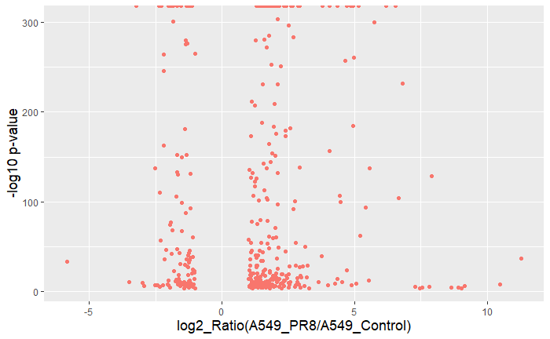

```r
ggplot(combined_res) +
        geom_point(aes(x = PR8_infected, y = -log10(PR8_pvalue), color = PR8_threshold)) +
        xlab("log2_Ratio(A549_PR8/A549_Control)") +
        ylab("-log10 p-value") +
        theme(legend.position = "none",
              plot.title = element_text(size = rel(1.5), hjust = 0.5),
              axis.title = element_text(size = rel(1.25)))
```

### Volcano plot results

Here in red are all the DEGs with p-value < 0.05. DEGs with p-value > 0.05 are shown in blue. As you can see all DEGs here are statistically significant. However, upon further examination, the dataset from the paper only includes statistically significant DEGs. However, analysis is still possible. Overall the main difference is that CA01 infected cells have one DEG that is much more downregulated. The line below shows the DEG, which is TNFAIP8L3 (Tumor necrosis factor alpha induced protein 8-like 3. It acts as a lipid transfer protein. However, just oen gene is not enough to draw any conclusions.

```r
combined_res[combined_res$CA01_infected < -5,]
```

|  | CA01_infected | PR8_infected | CA01_pvalue | PR8_pvalue | CA01_threshold | PR8_threshold |
| --- | --- | --- | --- | --- | --- | --- |
| TNFAIP8L3 | -9.88202 | -1.221981 | 6.51e-17 | 8.27e-13 | TRUE | TRUE |

## Pathway analysis of significant results

```r
# Load in dataset for human genes
data(kegg.sets.hs)

# The gage function takes in a vector of foldchanges with the name of each element being the geneid. It returns a list of pathways with the increased and decreased pathways stored in "greater" and "less" respectively.
foldchanges_ca01 <- res_ca01$`log2_Ratio(A549_CA01/A549_Control)`
names(foldchanges_ca01) <- res_ca01$geneID
keggres_ca01 <- gage(foldchanges_ca01, gsets=kegg.sets.hs)

foldchanges_pr8 <- res_pr8$`log2_Ratio(A549_PR8/A549_Control)`
names(foldchanges_pr8) <- res_pr8$geneID
keggres_pr8 <- gage(foldchanges_pr8, gsets=kegg.sets.hs)

#removing all NA values
keggres_ca01$greater <- keggres_ca01$greater[!is.na(keggres_ca01$greater[,1]),]
keggres_ca01$less <- keggres_ca01$less[!is.na(keggres_ca01$less[,1]),]
keggres_ca01$stats <- keggres_ca01$stats[!is.na(keggres_ca01$stats[,1]),]

#removing all NA values

keggres_pr8$greater <- keggres_pr8$greater[!is.na(keggres_pr8$greater[,1]),]
keggres_pr8$less <- keggres_pr8$less[!is.na(keggres_pr8$less[,1]),]
keggres_pr8$stats <- keggres_pr8$stats[!is.na(keggres_pr8$stats[,1]),]

#Subsetting significant pathways (p-value < 0.05)
ca01_up_path <- keggres_ca01$greater[keggres_ca01$greater[,3] < 0.05,]
ca01_down_path <- keggres_ca01$less[keggres_ca01$less[,3] < 0.05,]
pr8_up_path <- keggres_pr8$greater[keggres_pr8$greater[,3] < 0.05,]
pr8_down_path <- keggres_pr8$less[keggres_pr8$less[,3] < 0.05,]

# Additional naming needed for ca01_down_path is needed because there is only 1 pathway with p-value < 0.05, leading to a vector being returned instead of a matrix.
ca01_down_path <- matrix(ca01_down_path, nrow = 1, ncol = 6)
rownames(ca01_down_path) <- rownames(keggres_ca01$less)[1]
colnames(ca01_down_path) <- colnames(keggres_ca01$less)

# Combining significant pathways into one list.
pathway_results <- list(ca01_up_path = ca01_up_path, ca01_down_path = ca01_down_path, pr8_up_path = pr8_up_path, pr8_down_path = pr8_down_path)
```

```r
# Print out pathways up and down regulated with p-values < 0.05 for infection of A549 cells with ca01 and PR8 strains of H1N1
writeLines("Upregualted pathways in CA01 infected A549 cells")
```

```
Upregualted pathways in CA01 infected A549 cells
```

```r
ca01_up_path
```

```
                                                p.geomean stat.mean      p.val     q.val set.size       exp1
hsa05160 Hepatitis C                           0.01791646  2.214589 0.01791646 0.1424625       14 0.01791646
hsa04620 Toll-like receptor signaling pathway  0.02276254  2.115174 0.02276254 0.1424625       13 0.02276254
hsa04622 RIG-I-like receptor signaling pathway 0.02671172  2.055039 0.02671172 0.1424625       11 0.02671172
hsa04623 Cytosolic DNA-sensing pathway         0.04385039  1.815840 0.04385039 0.1506967       10 0.04385039
hsa04630 Jak-STAT signaling pathway            0.04709272  1.730074 0.04709272 0.1506967       16 0.04709272
```

```r
writeLines("\n\nUpregualted pathways in PR8 infected A549 cells")
```

```
Upregualted pathways in PR8 infected A549 cells
```

```r
pr8_up_path
```

```
                                     p.geomean stat.mean      p.val     q.val set.size       exp1
hsa05160 Hepatitis C                0.03374636  1.903190 0.03374636 0.4394026       15 0.03374636
hsa04630 Jak-STAT signaling pathway 0.04625291  1.749914 0.04625291 0.4394026       14 0.04625291
```

```r
writeLines("\n\nDownregualted pathways in CA01 infected A549 cells")
```

```
Downregualted pathways in CA01 infected A549 cells
```

```r
ca01_down_path
```

```
                         p.geomean stat.mean      p.val     q.val set.size       exp1
hsa04510 Focal adhesion 0.02193205 -2.190109 0.02193205 0.3509127       11 0.02193205
```

```r
writeLines("\n\nDownregualted pathways in PR8 infected A549 cells")
```

```
Downregualted pathways in PR8 infected A549 cells
```

```r
pr8_down_path
```

```
                                   p.geomean stat.mean      p.val     q.val set.size       exp1
hsa04512 ECM-receptor interaction 0.01316771 -2.477159 0.01316771 0.1553152       13 0.01316771
hsa05200 Pathways in cancer       0.02244660 -2.077078 0.02244660 0.1553152       20 0.02244660
hsa04510 Focal adhesion           0.02452346 -2.028822 0.02452346 0.1553152       23 0.02452346
```

```r
# Funciton I made to more easily generate the pathway analysis image and load in the generated png. Due to the size and resolution of the images, they are not vieable in the html file. However, it is viewable in R studio by clicking on "Show in new window" after the images are generated.
displayPathView <- function(foldchanges, pathway, group = ""){
  pathview(gene.data = foldchanges, pathway.id = pathway, out.suffix = group)
  img <- readPNG(paste(pathway, group, "png", sep = "."))
  plot.new()
  title(paste(group, pathway, sep = ": "))
  rasterImage(img,0,0,1,1)
}
```

```
Info: Working in directory C:/Users/Michael Li/Documents/BIMM143/Project_2
Info: Writing image file hsa05160.ca01_up.png
```

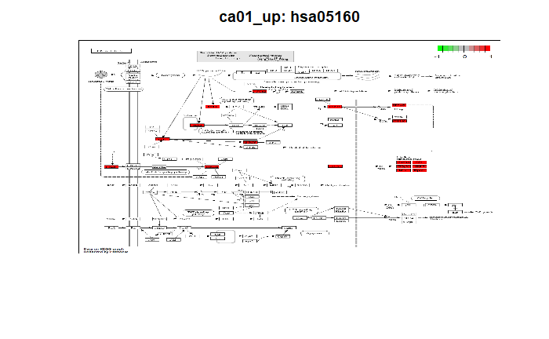

```r
# Here I look at the hsa05160 pathway, which is the Hepatitis C infection pathway, as it is upregulated in both types of infections.
displayPathView(foldchanges_ca01, "hsa05160", "ca01_up")
```

```
Info: Working in directory C:/Users/Michael Li/Documents/BIMM143/Project_2
Info: Writing image file hsa05160.pr8_up.png
```

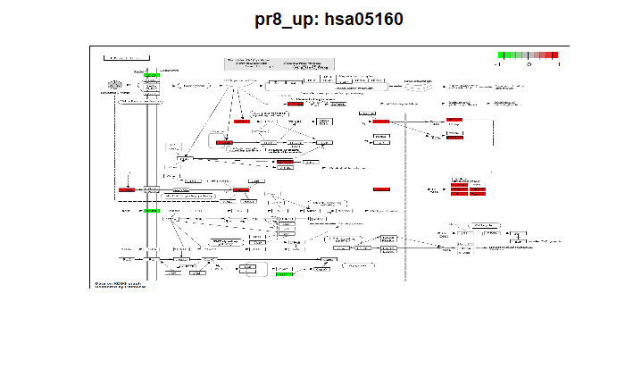

```r
displayPathView(foldchanges_pr8, "hsa05160", "pr8_up")
```

```
Info: Working in directory C:/Users/Michael Li/Documents/BIMM143/Project_2
Info: Writing image file hsa04620.ca01_up.png
```

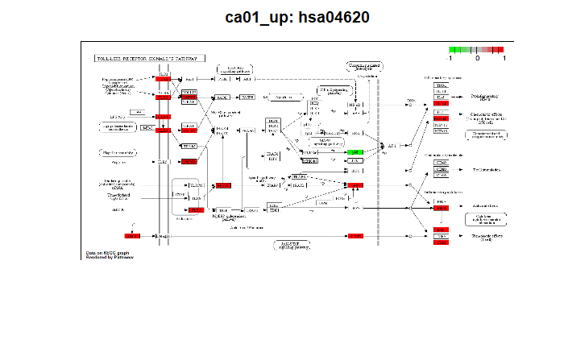

```r
# Here I look at the hsa04620 pathway, which is the Toll-like receptor pathway, as it is upregulated only in CA01 infected A549 cells.
displayPathView(foldchanges_ca01, "hsa04620", "ca01_up")
```

```
Info: Working in directory C:/Users/Michael Li/Documents/BIMM143/Project_2
Info: Writing image file hsa04622.ca01_up.png
```

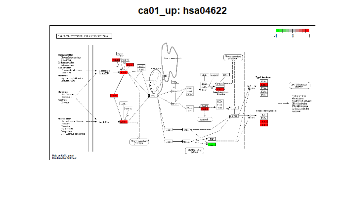

```r
# Here I look at the hsa04622 pathway, which is the RIG-I-like receptor pathway, as it is upregulated only in CA01 infected A549 cells.
displayPathView(foldchanges_ca01, "hsa04622", "ca01_up")
```

```
Info: Working in directory C:/Users/Michael Li/Documents/BIMM143/Project_2
Info: Writing image file hsa04623.ca01_up.png
```

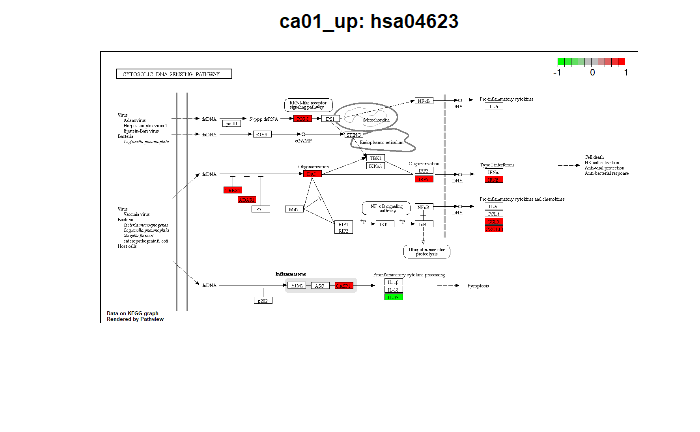

```r
# Here I look at the hsa04623 pathway, which is the cytosolic DNA sensor pathway, as it is upregulated only in CA01 infected A549 cells.
displayPathView(foldchanges_ca01, "hsa04623", "ca01_up")
```

```
Info: Working in directory C:/Users/Michael Li/Documents/BIMM143/Project_2
Info: Writing image file hsa04510.ca01_down.png
```

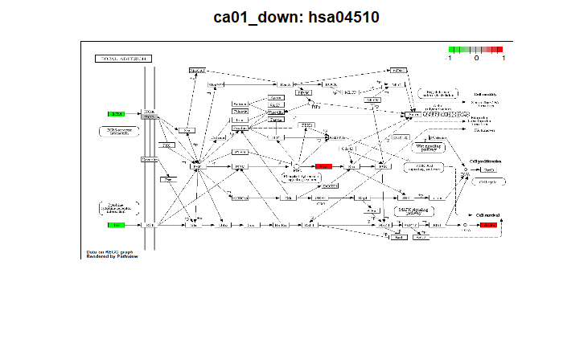

```r
# Here I look at the hsa04510 pathway, which is the focal adhesion pathway, as it is downregulated in both types of infections.
displayPathView(foldchanges_ca01, "hsa04510", "ca01_down")
```

```
Info: Working in directory C:/Users/Michael Li/Documents/BIMM143/Project_2
Info: Writing image file hsa04512.pr8_down.png
```

[figure not shown]

```r
# Here I look at the hsa04512 pathway, which is the ECM-receptor interaction pathway, as it is downregulated only in PR8 infected cells.
displayPathView(foldchanges_pr8, "hsa04512", "pr8_down")
```

```
Info: Working in directory C:/Users/Michael Li/Documents/BIMM143/Project_2
Info: Writing image file hsa05200.pr8_down.png
Info: some node width is different from others, and hence adjusted!
```

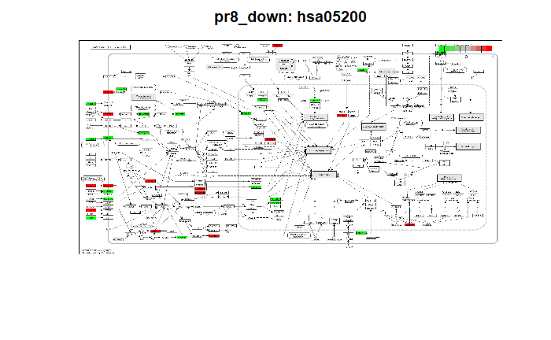

```r
# Here I look at the hsa05200 pathway, which is Pathways in cancer, as it is downregulated only in PR8 infected cells.
displayPathView(foldchanges_pr8, "hsa05200", "pr8_down")
```

### Pathway analysis results

We see that CA01 infected cells uniquely showed up-regulation in Toll-like receptor signaling, RIG-I-like receptor signaling, and cystolic DNA-sensing pathway, in addition to sharing with PR8 infected cells the up-regulated pathways of Hepatitis C infection pathway and JAK-STAT signaling pathway. We also see that PR8 infected cells uniquely showed down-regulation in the ECM-receptor interaction pathway and pathways in cancer, in addition to sharing with CA01 infected cells the down-regulated pathway of focal adhesion.

## Overall analysis/discussion/conclusion of RNAseq data based on RPKM

In terms of pathway analysis it is more useful to just look at pathways that are only up or down regulated in one group.

In pandemic strains, the Toll-like receptor (TLR) signaling pathway, RIG-I-like signaling pathway, and cytosolic DNA-sensing pathway are uniquely up-regulated. The TLR pathway leads to pro-inflammatory, chemotactic, antiviral, and T cell stimulation. like mentioned before, the RIG-I pathway senses ssRNA (it also senses dsRNA). Its downstream effects lead to activation of various JAK-STAT signaling pathways via interferons and inflammatory cytokines. It’s interesting that the cytosoli DNA sensor pathway (which senses DNA in the cytosol as a sign of viral infection) is upregulated. However, this could be a false positive as there are many overlapping genes in this pathway and the previously mentioned pathways.

In the seasonal strain (PR8), the ECM-receptor interaction pathway and cancer pathways are uniquely down-regulated. This pathway involves various integrins, which allow cells to bind to the extracellular matrix. This means that A549 (lung epithelial cells) cells are more motile when infected by the PR8 strain compared to cells infected by the CA01 strain and uninfected cells. At the same time, PR8 infected cells also experience down-regulation in various cancer related pathways like proliferation, evading apoptosis, and angiogenesis. This lower cell proliferation could lead to a slower rate of infection between cells as if an infected cell divides while housing a virus, it will have infected 2 cells for free.

# Answering the Scientific Question and Discussion

The scientific question posed at the beginning was: What differences in the sequences of each segment of the segmented genome and expression of infected cells exist between the H1N1 from the 2009 Swine flu pandemic and non-pandemic H1N1 (specifically the strain A/Puerto Rico/8/1934) that may contribute to differences in severity?

Our hypothesis was: If there is a difference in gene sequences, then severity related differences will be seen in the NS1 and NS2 sequences with pandemic strains having more closely correlated scores and seasonal strains having closely correlated scores, and if there is a difference in transcription of infected cells, then we should see different levels of expression for immune system related genes with pandemic strains inducing higher levels of expression of those genes.

In our sequence scores heatmap, we see a geographic correlation between most segment sequences of the CA4 pandemic strain and the Alabama seasonal strain from 2020. Interestingly enough the pandemic strains of the H3N2 virus in Hong Kong 1968 and of the H1N1 virus in USSR 1977 share relatively similar matrix proteins (M1 and M2) and non-structural proteins (NS1 and NS2). This shows that the matrix proteins and non-structural proteins could play a role in disease severity.

Through the various analysis techniques applied to the RNAseq data set in the second part, we overall see CA01 infected cells having a higher expression of immune related genes and, by extension, more immune pathways being up-regulated. One unexpected result was that cell adhesion, proliferation, and survival was relatively down-regulated in the seasonal PR8 H1N1 infected cells. Like mentioned previously, this could lend to a lower disease severity as it slows the rate of infection between cells. It should also be noted that influenza A (H1N1, H3N2, etc.) are enveloped, so their release does not require the death of the host cell. This means that it is in their best interest for the host to not die.

There are some limitations of the data used in this project that would require further investigation to establish anything concrete. First, the sample size for the RNAseq data is n = 1 for each group (control and experimental groups each have a sample size of 1). For the sequence data, it would be better if we compared all known strains as we still see a lot of noise with this small sample size. This results in the data used being more suitable to study the specific strain and their evolution rather than pandemic and seasonal strains as a whole.

Going forward, it would be interesting to look into the role of matrix proteins in facilitating infection and disease severity. It would also be interesting to further confirm whether or nto seasonal H1N1 strains do lead to lower cell adhesion, proliferation, and survival. It would be reasonable to believe that cell death and tissue damage contributes to pathology, so it is interesting that this is down regulated in only the PR8 strain. Due to the limitation of sample size as mentioned previously, more research needs to be conducted.

# References

Clark, A. M., Nogales, A., Martinez-Sobrido, L., Topham, D. J., & DeDiego, M. L. (2017). Functional Evolution of Influenza Virus NS1 Protein in Currently Circulating Human 2009 Pandemic H1N1 Viruses. Journal of virology, 91(17), e00721-17. https://doi.org/10.1128/JVI.00721-17

Li, Jing et al. Transcriptome Profiling Reveals Differential Effect of Interleukin-17A Upon Influenza Virus Infection in Human Cells. 2019 Frontiers in Microbiology. https://www.frontiersin.org/articles/10.3389/fmicb.2019.02344/full

Pagani, Isabel et al. Mutations Conferring increased Sensitivity to Tripartite Motif 22 Restriction Accumulated Progressively in the Nucleoprotein of Seasonal Influenza A (H1N1) viruses between 1918 and 2009. 2018 American Society for Microbiology. DOI:10.1128/mSphere.00110-18

Pinto, A. K., Williams, G. D., Szretter, K. J., White, J. P., Proença-Módena, J. L., Liu, G., Olejnik, J., Brien, J. D., Ebihara, H., Mühlberger, E., Amarasinghe, G., Diamond, M. S., & Boon, A. C. (2015). Human and murine IFIT1 proteins do not restrict infection of negative-sense RNA viruses of the Orthomyxoviridae, Bunyaviridae, and Filoviridae families. Journal of Virology, 89(18), 9465–9476. https://doi.org/10.1128/jvi.00996-15

Zhu, J., Zhang, Y., Ghosh, A., Cuevas, R. A., Forero, A., Dhar, J., Ibsen, M. S., Schmid-Burgk, J. L., Schmidt, T., Ganapathiraju, M. K., Fujita, T., Hartmann, R., Barik, S., Hornung, V., Coyne, C. B., & Sarkar, S. N. (2014). Antiviral activity of human OASL protein is mediated by enhancing signaling of the RIG-I RNA sensor. Immunity, 40(6), 936–948. https://doi.org/10.1016/j.immuni.2014.05.007